# R Notebook

# Visualizing Carbon Dioxide Levels

These data are calculated by analyzing ice cores. Over time, gas gets trapped in the ice of Antarctica. Scientists can take samples of that ice and see how much carbon is in it. The deeper you go into the ice, the farther back in time you can analyze!

The first dataset comes from World Data Center for Paleoclimatology, Boulder and NOAA Paleoclimatology Program and describes the carbon dioxide levels back thousands of years “Before Present” (BP) or before January 1, 1950.

The second dataset explores carbon dioxide starting at year zero up until the recent year of 2014. This dataset was compiled by the Institute for Atmospheric and Climate Science (IAC) at Eidgenössische Technische Hochschule in Zürich, Switzerland.

In order to understand the information in these datasets, it’s important to understand two key facts about the data:

The metric for carbon dioxide level is measured as parts per million or CO2 ppmv. This number describes the number of carbon dioxide molecules per one million gas molecules in our atmosphere.

The second metric describes years before present, which is “a time scale used mainly in … scientific disciplines to specify when events occurred in the past… standard practice is to use 1 January 1950 as the commencement date of the age scale, reflecting the origin of practical radiocarbon dating in the 1950s. The abbreviation “BP” has alternatively been interpreted as “Before Physics” that is, before nuclear weapons testing artificially altered the proportion of the carbon isotopes in the atmosphere, making dating after that time likely to be unreliable.” This means that saying “the year 20 BP” would be the equivalent of saying “The year 1930.”

Let’s get started!

# Carbon Dioxide over Time Line Graph

1.Let’s first explore the dataset containing the data from the World Data Center for Paleoclimatology, Boulder and NOAA Paleoclimatology Program. Import the `"carbon_dioxide_levels.csv"` and save it to a new variable named `noaa_data`.

```r
# load libraries and data
library(readr)
library(dplyr)
library(ggplot2)
noaa_data <- read.csv("carbon_dioxide_level.csv")
```

2.Inspect the head of the data frame. What are the names of the two columns? What types of values are in each?

```r
options(scipen=10000) #removes scientific notation
#inspect the data frame here:
head(noaa_data)
```

|  | Age_yrBP | CO2_ppmv |
| --- | --- | --- |
| 1 | 137 | 280.4 |
| 2 | 268 | 274.9 |
| 3 | 279 | 277.9 |
| 4 | 395 | 279.1 |
| 5 | 404 | 281.9 |
| 6 | 485 | 277.7 |

```r
str(noaa_data)
```

```
'data.frame':   1096 obs. of  2 variables:
 $ Age_yrBP: int  137 268 279 395 404 485 559 672 754 877 ...
 $ CO2_ppmv: num  280 275 278 279 282 ...
```

3.Let’s visualize this data. First, create a new variable named `noaa_viz` that is equal to a new ggplot() object and assign `noaa_data` as its data argument. Be sure to state the name of the variable after you define it so that it is rendered to the R notebook.

4.Define your scales by creating an aesthetic mapping that maps `Age_yrBP` on the x-axis and `CO2_ppmv` on the y-axis as part of the canvas.

5.In climate science, it’s common to create line graphs to best portray the fluctuations in the levels of carbon dioxide. Add a `geom_line()` layer to the `noaa_viz` plot.

7.Tweak the axis labels so they are more descriptive than the column headers. The x-axis should read `"Years Before Today (0=1950)"` and the y-axis should read `"Carbon Dioxide Level (Parts Per Million)"`

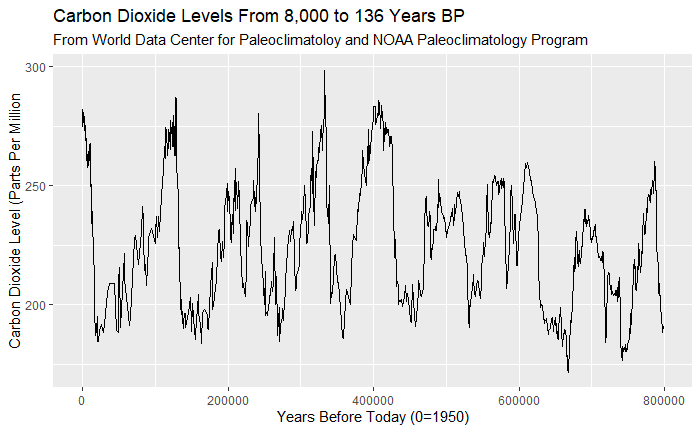

```r
#Create NOAA Visualization here:
noaa_viz <- ggplot(noaa_data, aes(x=Age_yrBP, y=CO2_ppmv)) +
            geom_line() +
            labs(title = "Carbon Dioxide Levels From 8,000 to 136 Years BP", subtitle = "From World Data Center for Paleoclimatoloy and NOAA Paleoclimatology Program", x="Years Before Today (0=1950)", y="Carbon Dioxide Level (Parts Per Million")
noaa_viz
```

8.Currently, the order of the years is counterintuitive. Since the most recent date is the date closest to 0, or 1950 as Before Physics is described, we want the years on the x-axis arranged in descending order. Add this to noaa_viz:

noaa_viz + scale_x_reverse(lim=c(800000,0))

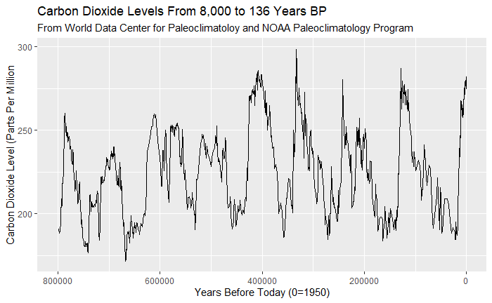

```r
#Create NOAA Visualization here:
noaa_viz <- ggplot(noaa_data, aes(x=Age_yrBP, y=CO2_ppmv)) +
            geom_line() +
            labs(title = "Carbon Dioxide Levels From 8,000 to 136 Years BP", subtitle = "From World Data Center for Paleoclimatoloy and NOAA Paleoclimatology Program", x="Years Before Today (0=1950)", y="Carbon Dioxide Level (Parts Per Million") +
            scale_x_reverse(lim=c(800000,0))
noaa_viz
```

# Carbon Dioxide Levels in the last Two Millennia

9.In the second code block, let’s explore the second dataset containing the data for the last 2014 years. Import the `"yearly_co2.csv"` file and save it to a new variable named `iac_data`.

```r
iac_data <- read.csv("yearly_co2.csv")
```

10.Inspect the head. What are the names of the four columns? What types of values are in each? Note that the `data_mean_globa`l is an equivalent metric to `CO2_ppmv`. We will not be using the other two columns in this project. What’s different about the year column in this dataset?

```r
head(iac_data)
```

|  | year | data_mean_global | data_mean_nh | data_mean_sh |
| --- | --- | --- | --- | --- |
| 1 | 0 | 277.454 | 277.454 | 277.454 |
| 2 | 1 | 277.137 | 277.137 | 277.137 |
| 3 | 2 | 277.160 | 277.160 | 277.160 |
| 4 | 3 | 277.158 | 277.158 | 277.158 |
| 5 | 4 | 277.157 | 277.157 | 277.157 |
| 6 | 5 | 277.167 | 277.167 | 277.167 |

```r
str(iac_data)
```

```
'data.frame':   2015 obs. of  4 variables:
 $ year            : int  0 1 2 3 4 5 6 7 8 9 ...
 $ data_mean_global: num  277 277 277 277 277 ...
 $ data_mean_nh    : num  277 277 277 277 277 ...
 $ data_mean_sh    : num  277 277 277 277 277 ...
```

11.Again, let’s create a new ggplot() object named `iac_viz` and associate `iac_data` as its data argument. Let’s make a new variable named `iac_viz`. Be sure to state the name of the variable after you define it so that it is rendered to the R notebook.

12.Define your scales by creating an aesthetic mapping that maps `year` on the x-axis and `data_mean_global` on the y-axis as part of the canvas.

Note: The dataset column headers are different than the ones in the previous data frame. Years are chornological starting from 0 up to 2014, not in terms of BP. The `data_mean_global` references the same metric as `C02_ppmv` for carbon dioxide average parts per million in the earth’s atmosphere.

13.A line graph also makes sense for these data. Let’s explore how much carbon dioxide was stored in the atmosphere over the past two millennia by adding a `geom_line()` layer to the `iac_viz` plot.

14.This plot still needs labels to add context to the plot. Title the plot `"Carbon Dioxide Levels over Time"` and add a subtitle that cites the data `"From Institute for Atmospheric and Climate Science (IAC)"`.

15.Tweak the axis labels so they are more descriptive than the column headers. The x-axis should read `"Year"` and the y-axis should read `"Carbon Dioxide Level (Parts Per Million)"`.

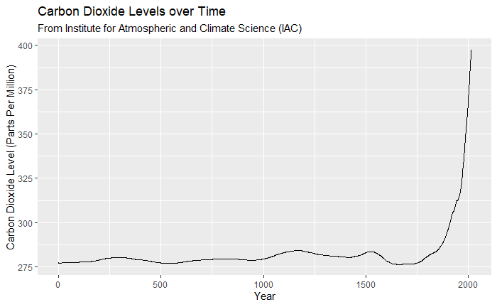

```r
iac_viz <- ggplot(iac_data, aes(x=year, y=data_mean_global)) +
          geom_line() +
          labs(title = "Carbon Dioxide Levels over Time", subtitle = "From Institute for Atmospheric and Climate Science (IAC)", x="Year", y="Carbon Dioxide Level (Parts Per Million)")
iac_viz
```

```r
millenia_max <- max(noaa_data$CO2_ppmv)
millenia_max
```

```
[1] 298.6
```

17.Now that we have the maximum number in the noaa_data let’s map it on our `iac_data` plot. There’s a geom in ggolot called `geom_hline()` that plots a horizontal line. Add a `geom_hline()` layer to `iaC_viz` that has a `yintercept` value in its aesthetic mapping of `millennia_max`.

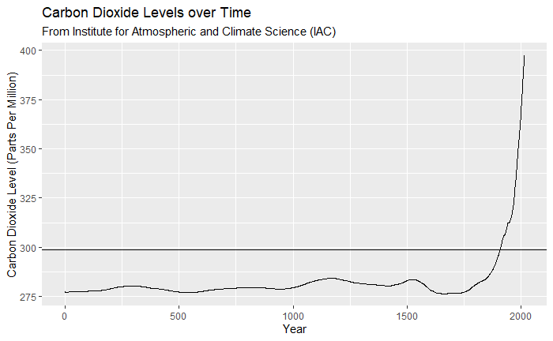

```r
iac_viz <- ggplot(iac_data, aes(x=year, y=data_mean_global)) +
          geom_line() +
          labs(title = "Carbon Dioxide Levels over Time", subtitle = "From Institute for Atmospheric and Climate Science (IAC)", x="Year", y="Carbon Dioxide Level (Parts Per Million)") +
          geom_hline(aes(yintercept = millenia_max))
iac_viz
```

18.Add one more argument to the horizonal line’s aesthetic mapping so that the legend can display information about what the line represents. Assign the value of the `linetype` argument as `"Historical CO2 Peak before 1950"`

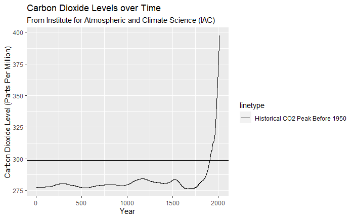

```r
iac_viz <- ggplot(iac_data, aes(x=year, y=data_mean_global)) +
          geom_line() +
          labs(title = "Carbon Dioxide Levels over Time", subtitle = "From Institute for Atmospheric and Climate Science (IAC)", x="Year", y="Carbon Dioxide Level (Parts Per Million)") +
          geom_hline(aes(yintercept = millenia_max, linetype="Historical CO2 Peak Before 1950"))
iac_viz
```